# Practical Machine Learning Project

zhouyanhui

November 19, 2015

# Background

Using devices such as Jawbone Up, Nike FuelBand, and Fitbit it is now possible to collect a large amount of data about personal activity relatively inexpensively. These type of devices are part of the quantified self movement – a group of enthusiasts who take measurements about themselves regularly to improve their health, to find patterns in their behavior, or because they are tech geeks. One thing that people regularly do is quantify how much of a particular activity they do, but they rarely quantify how well they do it. In this project, your goal will be to use data from accelerometers on the belt, forearm, arm, and dumbell of 6 participants. They were asked to perform barbell lifts correctly and incorrectly in 5 different ways. More information is available from the website here: http://groupware.les.inf.puc-rio.br/har (see the section on the Weight Lifting Exercise Dataset).

# Data

The training data for this project are available here:  
https://d396qusza40orc.cloudfront.net/predmachlearn/pml-training.csv  
The test data are available here:  
https://d396qusza40orc.cloudfront.net/predmachlearn/pml-testing.csv

# Motivation

The goal of this project is to predict the manner in which they did the exercise. This is the “classe” variable in the training set. And use any of the other variables to predict with. Then use the prediction model to predict 20 different test cases.

# Preprocessing

```r
library(caret)
```

Read data and partition.

```r
training<-read.csv("./pml-training.csv",  na.strings=c("NA","#DIV/0!",""))
testing<-read.csv("./pml-testing.csv",  na.strings=c("NA","#DIV/0!",""))
set.seed(12123)

inTrain<-createDataPartition(training$classe, p=0.6, list = FALSE)
newTraining<-training[inTrain,]
validating<-training[-inTrain,]
```

1. Remove first 7 variables that are not related to predicting the model

```r
newTraining <- newTraining[, -(1:7)]
```

2. Remove too many NA variables

```r
colNasProb <- vector()
training.names <- colnames(newTraining)
for(colName in training.names){
    naRowNum <- sum(is.na(newTraining[,colName]))
    totalRowNum <- nrow(newTraining)
    colNasProb[colName] <- naRowNum / totalRowNum
}
# remove the variables which has 95% nas or more
remainCols <- names(colNasProb[colNasProb < 0.95])
newTraining <- newTraining[, remainCols]
```

3. Remove near zero variance variables

```r
nzvs <- nearZeroVar(newTraining, saveMetrics = TRUE)
newTraining <- newTraining[, !nzvs$nzv]
```

4. Do the same to validation and testing

```r
remainCols<-colnames(newTraining)
validating<-validating[, remainCols]
testing<-testing[,remainCols[-length(remainCols)]]
```

# Modeling and Cross Validation

Build a decision tree by train using rpart method

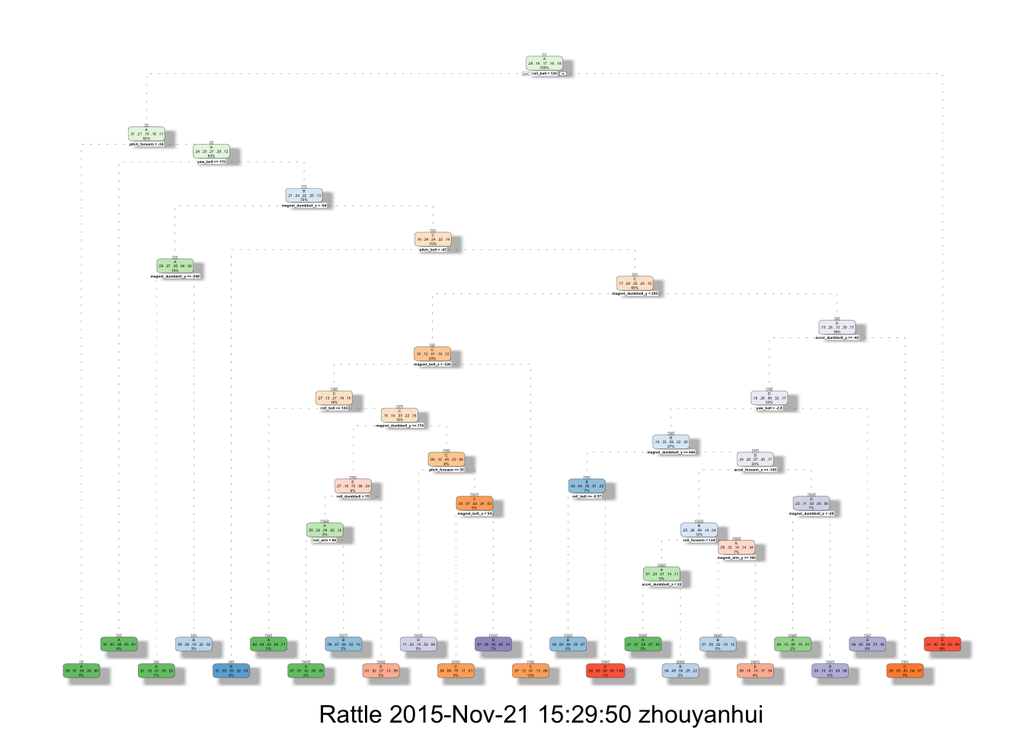

```r
suppressMessages(library(rpart))
suppressMessages(library(rpart.plot))
suppressMessages(library(rattle))
model <- rpart(classe ~ ., data = newTraining, method = 'class')
suppressWarnings(fancyRpartPlot(model))
```

Predict using validation samples by rpart model, and calculate the accuracy

```r
rpartPredict <- predict(model, validating, type = "class")
confusionMatrix(rpartPredict, validating$classe)
```

```
## Confusion Matrix and Statistics
##
##           Reference
## Prediction    A    B    C    D    E
##          A 1940  183   12   54   67
##          B   78 1037  138  127  167
##          C   98  139 1032  188   99
##          D   84  107   96  826   73
##          E   32   52   90   91 1036
##
## Overall Statistics
##
##                Accuracy : 0.7483
##                  95% CI : (0.7385, 0.7579)
##     No Information Rate : 0.2845
##     P-Value [Acc > NIR] : < 2.2e-16
##
##                   Kappa : 0.6815
##  Mcnemar's Test P-Value : < 2.2e-16
##
## Statistics by Class:
##
##                      Class: A Class: B Class: C Class: D Class: E
## Sensitivity            0.8692   0.6831   0.7544   0.6423   0.7184
## Specificity            0.9437   0.9194   0.9191   0.9451   0.9586
## Pos Pred Value         0.8599   0.6703   0.6632   0.6965   0.7963
## Neg Pred Value         0.9478   0.9236   0.9466   0.9309   0.9380
## Prevalence             0.2845   0.1935   0.1744   0.1639   0.1838
## Detection Rate         0.2473   0.1322   0.1315   0.1053   0.1320
## Detection Prevalence   0.2875   0.1972   0.1983   0.1512   0.1658
## Balanced Accuracy      0.9064   0.8013   0.8367   0.7937   0.8385
```

Based on the accuracy with rpart, we know it can be boosted by random reforest.

```r
suppressMessages(library(randomForest))
rfModel <- randomForest(classe ~. , data=newTraining)
rfPredict <- predict(rfModel, validating, type = 'class')
ret <- confusionMatrix(rfPredict, validating$classe)
ret
```

```
## Confusion Matrix and Statistics
##
##           Reference
## Prediction    A    B    C    D    E
##          A 2231   10    0    0    0
##          B    0 1503    4    0    0
##          C    1    5 1363   13    2
##          D    0    0    1 1270    5
##          E    0    0    0    3 1435
##
## Overall Statistics
##
##                Accuracy : 0.9944
##                  95% CI : (0.9925, 0.9959)
##     No Information Rate : 0.2845
##     P-Value [Acc > NIR] : < 2.2e-16
##
##                   Kappa : 0.9929
##  Mcnemar's Test P-Value : NA
##
## Statistics by Class:
##
##                      Class: A Class: B Class: C Class: D Class: E
## Sensitivity            0.9996   0.9901   0.9963   0.9876   0.9951
## Specificity            0.9982   0.9994   0.9968   0.9991   0.9995
## Pos Pred Value         0.9955   0.9973   0.9848   0.9953   0.9979
## Neg Pred Value         0.9998   0.9976   0.9992   0.9976   0.9989
## Prevalence             0.2845   0.1935   0.1744   0.1639   0.1838
## Detection Rate         0.2843   0.1916   0.1737   0.1619   0.1829
## Detection Prevalence   0.2856   0.1921   0.1764   0.1626   0.1833
## Balanced Accuracy      0.9989   0.9947   0.9966   0.9933   0.9973
```

The accuracy is 0.994392, so according to cross validation the expected out of sample error rate is: 0.005608.

# Predict on Test Case

Predict the testing by random forest model.

```r
testPredict <- predict(rfModel, testing, type = "class")
testPredict
```

```
##  1  2  3  4  5  6  7  8  9 10 11 12 13 14 15 16 17 18 19 20
##  B  A  B  A  A  E  D  B  A  A  B  C  B  A  E  E  A  B  B  B
## Levels: A B C D E
```

# Conclusion

Remove unuseful varibale which have too many NAs, or near zero variance. I make two partition of the raw training data to training and validating data, and then validate the model by cross validation. Firstly, I use decision tree to have a try on modeling on training data. According to the decision tree model, I guess making a random forest model may get a better accuracy. So, I got the final random forest model which had a very low out of sample error rate.